# HW11

Claire

2018年12月17日

# 14.16

## a.

##### 98.3102

```r
98.6-0.0138*21
```

```
## [1] 98.3102
```

## b.

##### -0.0102

```r
98.3-98.3102
```

```
## [1] -0.0102
```

##### 0.0898

```r
98.4-98.3102
```

```
## [1] 0.0898
```

## c.

##### [99.6822-96.9382]

```r
98.3102+1.96*0.7
```

```
## [1] 99.6822
```

```r
98.3102-1.96*0.7
```

```
## [1] 96.9382
```

## d.

##### 不會，因為98.6包含在[99.6822-96.9382]的區間中，代表是在95%信心水準下能預期的範圍。

# 14,28

## a.

##### b1，因為它是用100個參考樣本算出來的回歸線斜率。

## b.

##### 區間為[-0.02213476- -0.005465237]，代表在95%信心水準下回歸線的斜率會落在[-0.02213476- -0.005465237]之間。

```r
t<-qt(0.025,df=98,lower.tail=F)#求t
low<--0.0138-t*0.0042;low
```

```
## [1] -0.02213476
```

```r
high<--0.0138+t*0.0042;high
```

```
## [1] -0.005465237
```

## c.

##### [-0.2213476–0.05465237]

```r
low_p<--0.02213476*10;low_p
```

```
## [1] -0.2213476
```

```r
low_h<--0.005465237*10;low_h
```

```
## [1] -0.05465237
```

# 14.36

## 1.

##### 跟報表上的77.62相同

```r
pre_er_time<-34.98+10.66*4;pre_er_time
```

```
## [1] 77.62
```

## 4.

##### 我會更想知道他的PI值，因為我不想錯過任何可能噴發的時間，所以光是知道平均值有點不夠，要保守一點抓時間的話要知道它可能噴發的時間範圍，也就是範圍比較大的PI才比較保險。

# 14.54

## a

##### y=30+0.576*x

## b.

##### 7.732438約等於表格中的T=7.73

```r
t<-0.57568/0.07445;t
```

```
## [1] 7.732438
```

## c.

### step 1

##### H0=回歸線斜率是0

##### Ha=回歸線斜率不是0

### step 2

#####b1=0.576，t= 7.73

### step 3

##### 根據表格上的內容，計算出來的p=0

### step 4

##### p=0，必定是差異顯著的，代表可以推翻H0的假設

### step 5

##### 證據顯示回歸線斜率跟0是差異顯著的，可以認定回歸線斜率不是0

## d.

##### [0.4282564-0.7237436]，代表在95%信心水準下斜率會落在#[0.4282564-0.7237436]之間，也就是爸爸每多長一公分，在95%信心水準下高出0.4282564-0.7237436公分。

```r
t<-qt(0.025,df=98,lower.tail=F)#求t
low<-0.576-t*0.07445;low
```

```
## [1] 0.4282564
```

```r
high<-0.576+t*0.07445;high
```

```
## [1] 0.7237436
```

# 14.56

## a.

##### 計算出的結果為67.44，約等於表格上的67.4。

```r
30+0.576*65
```

```
## [1] 67.44
```

## b.

##### [64.946 -75.612]

##### 在大學生中，爸爸身高是70inches的學生有95%身高會落在 64.946 -75.612 之間。

##### 在隨機抽樣之下，有95%機率當一個學生的爸爸身高是70inches，這個學生的身高落在在 64.946 -75.612 之間。

## c.

##### [71.596,73.566]，代表在95%信心水準下，爸爸身高是74 inches的學生身高期望直(平均)會落在71.596-73.566之間

## d.

#### 因為PI是預測y的範圍，CI是預測y的平均值範圍。前者可能的範圍比較寬闊，因為沒有限制要平均值。從算式來看，在根號中PI也比CI多了s^2。

## e.

##### 它不符符合第二條要求的「沒有離群值」，在爸爸身高是55、65的地方各有一個殘差是4跟-11，屬於離群值。我們可以將這兩個離群值移除來討論，並註明討論的範圍。之後再針對離群值作個別研究和解釋。

# R practice

```r
cars <- read.csv("D:/OneDrive/文件/統計學/Vehicles.csv", stringsAsFactors=F)
head(cars)
```

```
##   Year Vehicle  GDP
## 1 1992 2907022 5615
## 2 1993 3238754 6205
## 3 1994 3570497 6784
## 4 1995 3874203 7397
## 5 1996 4146475 8037
## 6 1997 4411911 8717
```

### 估計簡單回歸式

```r
cars<-cars[,c("Vehicle","GDP")]
cars<-na.omit(cars)

cars_Vehicle<-cars$Vehicle
cars_GDP<-cars$GDP

#simple linear regression
RESULTS=lm(cars_Vehicle~cars_GDP, data=cars)
summary(RESULTS)
```

```
##
## Call:
## lm(formula = cars_Vehicle ~ cars_GDP, data = cars)
##
## Residuals:
##     Min      1Q  Median      3Q     Max
## -413891 -113513    3883  119749  334703
##
## Coefficients:
##              Estimate Std. Error t value Pr(>|t|)
## (Intercept) 1.606e+06  1.251e+05   12.84 3.06e-12 ***
## cars_GDP    3.055e+02  1.022e+01   29.89  < 2e-16 ***
## ---
## Signif. codes:  0 '***' 0.001 '**' 0.01 '*' 0.05 '.' 0.1 ' ' 1
##
## Residual standard error: 175800 on 24 degrees of freedom
## Multiple R-squared:  0.9738, Adjusted R-squared:  0.9727
## F-statistic: 893.2 on 1 and 24 DF,  p-value: < 2.2e-16
```

```r
#correlation coefficient
cor.test(cars_Vehicle,cars_GDP)
```

```
##
##  Pearson's product-moment correlation
##
## data:  cars_Vehicle and cars_GDP
## t = 29.886, df = 24, p-value < 2.2e-16
## alternative hypothesis: true correlation is not equal to 0
## 95 percent confidence interval:
##  0.9704225 0.9941627
## sample estimates:
##     cor
## 0.98683
```

```r
#ANOVA
anova(RESULTS)
```

```
## Analysis of Variance Table
##
## Response: cars_Vehicle
##           Df     Sum Sq    Mean Sq F value    Pr(>F)
## cars_GDP   1 2.7609e+13 2.7609e+13   893.2 < 2.2e-16 ***
## Residuals 24 7.4185e+11 3.0910e+10
## ---
## Signif. codes:  0 '***' 0.001 '**' 0.01 '*' 0.05 '.' 0.1 ' ' 1
```

##### 回歸式:Vehicle=(1.606e+06)+(3.055e+02)*GDP

### 假說檢定

#### step 1

##### siginificant level:α=0.05

##### H0:b1=0

##### H0:b1=!0

### step 2

##### b1=3.055e+02

##### t<-29.89

### step 3

##### p-value=2e-16

### step 4

##### p-value<α=0.05

### step 5

##### 結論足夠拒絕H0，證明b1不等於0

### 估計b1的信賴區間

```r
#手動計算
x.mean=mean(cars$GDP)
y.mean=mean(cars$Vehicle)

cars$xx=cars$GDP- x.mean
cars$yy=cars$Vehicle - y.mean
cars$xxyy=cars$xx*cars$yy
cars$xx2= cars$xx^2

##b1
b1 = sum(cars$xxyy)/sum(cars$xx2);b1
```

```
## [1] 305.5035
```

```r
##SSE
RESULTS=lm(cars_Vehicle~cars_GDP, data=cars)

yhat=RESULTS$fitted.values
SSE=sum((cars$Vehicle-yhat)^2);SSE
```

```
## [1] 741845713554
```

```r
##standard error of residual
s=sqrt(SSE/(nrow(cars)-2));s
```

```
## [1] 175813.1
```

```r
t<-qt(0.025,df=25,lower.tail = F)
se_b1<-s/sqrt(sum(cars$xx2));se_b1
```

```
## [1] 10.22215
```

```r
low_b1<-b1-t*se_b1;low_b1
```

```
## [1] 284.4506
```

```r
high_b1<-b1+t*se_b1;high_b1
```

```
## [1] 326.5564
```

##### b1的信賴區間=[284.4506,326.5564]

### 計算CI

```r
CI<-predict(RESULTS,data.frame(cars_GDP=c(9000,13000,17000)),interval="confidence",level=0.95)
CI
```

```
##       fit     lwr     upr
## 1 4355042 4263081 4447003
## 2 5577056 5501243 5652869
## 3 6799070 6667609 6930530
```

##### 當GDP是9000時，車子的數量的期望值有95%會落在[4263081,4447003]

##### 當GDP是13000時，車子的數量的期望值有95%會落在[5501243,5652869]

##### 當GDP是17000時，車子的數量的期望值有95%會落在[6667609,6930530]

### 計算PI

```r
PI=predict(RESULTS,data.frame(cars_GDP=c(9000,13000,17000)),interval="prediction",level=0.95)
PI
```

```
##       fit     lwr     upr
## 1 4355042 3980710 4729374
## 2 5577056 5206360 5947752
## 3 6799070 6413130 7185010
```

##### 當GDP是9000時，車子的數量有95%會落在[3980710,4729374]

##### 當GDP是13000時，車子的數量有95%會落在[5206360,5947752]

##### 當GDP是17000時，車子的數量有95%會落在[6413130,7185010]

### 畫圖

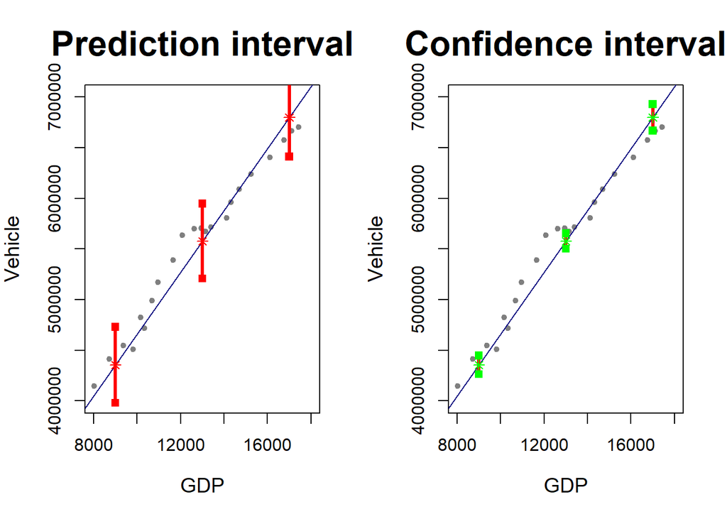

```r
#plotting
fit=PI[,1]
PI.low=PI[,2]
PI.high=PI[,3]

CI.low=CI[,2]
CI.high=CI[,3]

xx.test=c(9000,13000,17000)

par(mfrow=c(1,2))#把畫布分開(列，欄)


#plot PI
plot(cars_Vehicle~cars_GDP,data=cars,pch=20,col="gray50",main="Prediction interval",xlab="GDP",ylab="Vehicle",xlim=c(8000,18000),ylim=c(4e+06,7e+06),cex.main=2,cex.lab=1.2)

abline(RESULTS,col="navy")
for(i in 1:length(xx.test)){
  lines(c(xx.test[i],xx.test[i]),c(PI.low[i],PI.high[i]),col="red",lwd=3)
  points(xx.test[i],PI.low[i],col="red",pch=15)
  points(xx.test[i],PI.high[i],col="red",pch=15)
  points(xx.test[i],fit[i],col="red",pch=8)
}

#plot CI
plot(cars_Vehicle~cars_GDP,data=cars,pch=20,col="gray50",main="Confidence interval",xlab="GDP",ylab="Vehicle",xlim=c(8000,18000),ylim=c(4e+06,7e+06),cex.main=2,cex.lab=1.2)

abline(RESULTS,col="navy")
for(i in 1:length(xx.test)){
  lines(c(xx.test[i],xx.test[i]),c(CI.low[i],CI.high[i]),col="red",lwd=3)
  points(xx.test[i],CI.low[i],col="green",pch=15)
  points(xx.test[i],CI.high[i],col="green",pch=15)
  points(xx.test[i],fit[i],col="green",pch=8)
}
```

##### 可以從上圖發現PI的範圍比CI還要大，這是因為CI估計的是車子數量的平均值(期望值)，而PI估計的是可能的車子數量範圍的緣故

### Checking condition

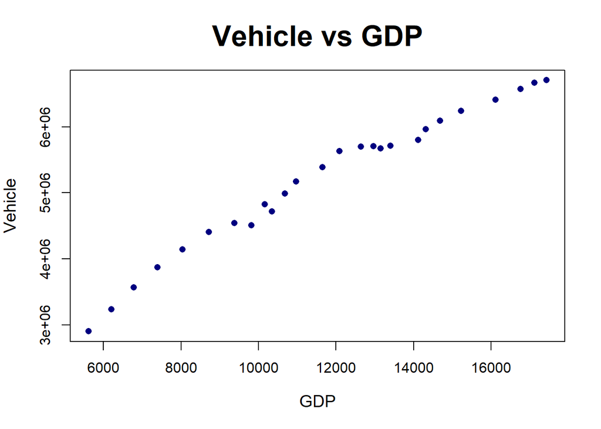

```r
#draw the scatter plot
##y vs x
plot(cars_Vehicle~cars_GDP,pch=16,cex=1,col="navy",
     main="Vehicle vs GDP",xlab="GDP",ylab="Vehicle",cex.main=2,cex.lab=1.2)
```

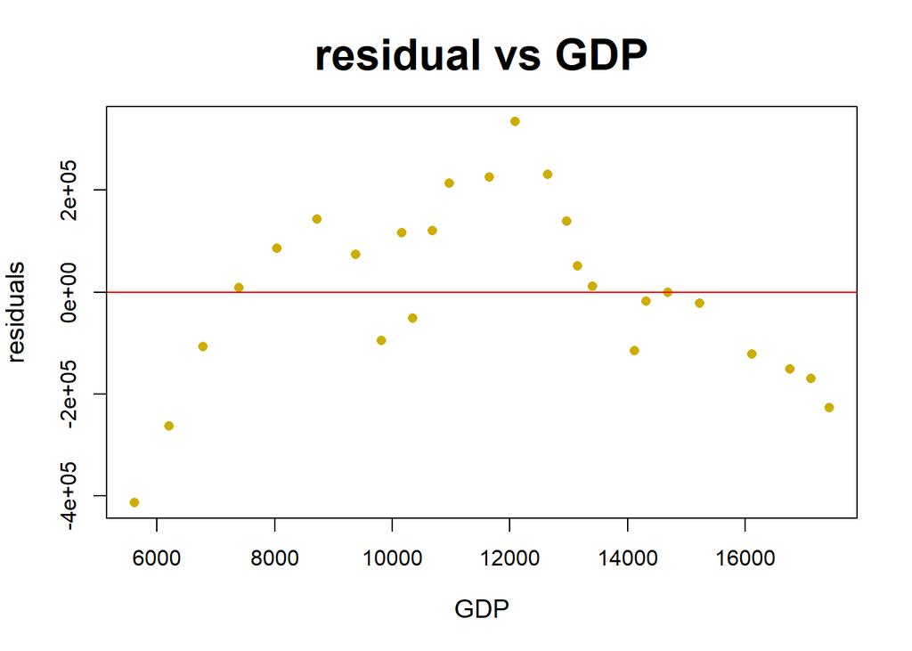

```r
#residuals vs x
res=RESULTS$res
plot(res~cars_GDP,pch=16,cex=1,col="gold3",
     main="residual vs GDP",xlab="GDP",ylab="residuals",cex.main=2,cex.lab=1.2)

abline(h=0,col="red")
```

##### 對於第二點不能有離群值的限制，我們可以從從y跟x的散佈圖跟殘差散佈圖得知沒有太明顯的離群值，符合該論述。

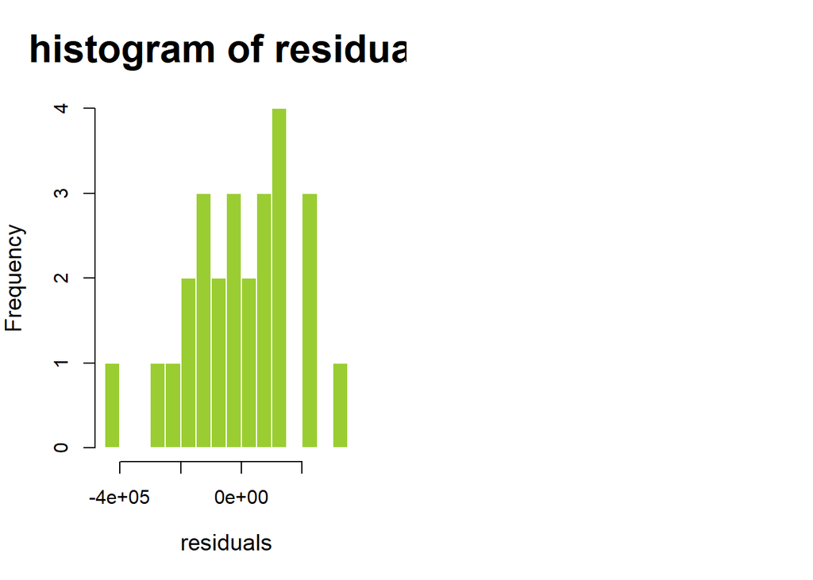

```r
#histogram of residuals
par(mfrow=c(1,2))

hist(res,breaks=20,border="white",col="olivedrab3",
     main="histogram of residual", xlab="residuals",
     cex.main=2,cex.lab=1.2)
```

##### 殘差近似於常態分佈，符合第四點要求

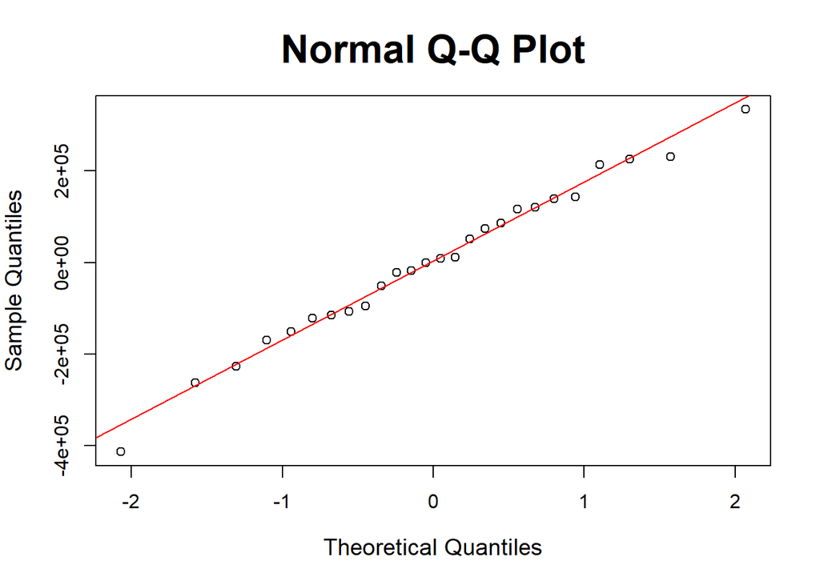

```r
#qqplot
qqnorm(res,cex.main=2,cex.lab=1.2)
qqline(res,col="red")
```